# Análisis y predicción de los accidentes ciclistas en la ciudad de Hamburgo - Modelos predictivos

Adrian Läufer

Mayo 2025

# 3. Modelos predictivos

Con tal de predicir la gravedad de los accidentes ciclistas según las diferentes variables definidas, aplicaremos a continuación dos modelos diferentes de aprendizaje automático: Random Forest y XGBoost.

A continuación cargaremos las librerias que necesitamos para aplicar los modelos predictivos.

```r
library(readr)
library(randomForest)
library(dplyr)
library(caret)
library(smotefamily)
library(xgboost)
library(Matrix)
```

Cargamos el dataset que contiene únicamente variables numéricas, ya que muchos algoritmos de aprendizaje automático requieren que las variables predictoras estén en este formato.

```r
df <- read_csv("data_complete_numeric.csv", locale = locale(encoding = "UTF-8"))
```

## 1. Random Forest

Antes de entrenar el modelo, aseguramos que la variable objetivo (category) esté en formato factor, ya que randomForest necesita esta estructura para realizar una clasificación.

```r
df$category <- as.factor(df$category)
```

Comprobamos si existen valores perdidos (NA) en alguna de las columnas, lo cual podría interferir con el entrenamiento del modelo.

```r
colSums(is.na(df))
```

```
          admin_region         admin_district           municipality
                     0                      0                      0
                  year                  month                   hour
                     0                      0                      0
              day_week               category          kind_accident
                     0                      0                      0
         type_accident           accident_car     accident_passenger
                     0                      0                      0
        accident_motor     accident_goodsroad         accident_other
                     0                   2180                  13356
               LINREFX                LINREFY road_surface_condition
                     0                      0                  11526
                   day          type_bikelane              direction
                     0                    141                    141
               surface                  width               pressure
                   141                    141                     16
              rainfall       sunshine_minutes            temperature
                    71                   1279                     14
              humidity             visibility    weather_description
                    14                      6                     77
        wind_direction          wind_category                traffic
                    88                    116                     24
```

Eliminamos las columnas que presentan mayor cantidad de valores perdidos y que, por tanto, podrían perjudicar o incluso evitar la creación del modelo. Además posteriormente eliminamos las filas que siguen conteniendo valores nulos, para tener un conjunto de datos limpio.

```r
# Quitamos las columnas con mayor cantidad de valores nulos
df_model <- df %>% dplyr::select(-accident_other, -road_surface_condition, -accident_goodsroad, -sunshine_minutes)

# Quitamos las filas con valores nulos
df_model <- na.omit(df_model)
```

Dividimos el conjunto de datos en entrenamiento (70%) y prueba (30%).

```r
# Determinamos los conjuntos de entrenamiento y de test
set.seed(123)
train_indices <- sample(1:nrow(df_model), 0.7 * nrow(df_model))
train <- df_model[train_indices, ]
test  <- df_model[-train_indices, ]

# Realizamos el modelo random forest
modelo_rf <- randomForest(category ~ ., data = train, ntree = 50, importance = TRUE)
```

Realizamos las predicciones sobre el conjunto de prueba utilizando el modelo entrenado.

```r
pred <- predict(modelo_rf, newdata = test)
```

Finalmente construimos una matriz de confusión para comparar las predicciones del modelo con las categorías reales. Así podemos evaluar el rendimiento del modelo.

```r
# Matriz de confusión
confusion <- confusionMatrix(pred, test$category)
print(confusion)
```

```
Confusion Matrix and Statistics

          Reference
Prediction    1    2    3
         1    0    0    0
         2    0    6    3
         3    7  523 5371

Overall Statistics

               Accuracy : 0.9098
                 95% CI : (0.9022, 0.917)
    No Information Rate : 0.9093
    P-Value [Acc > NIR] : 0.4573

                  Kappa : 0.0191

 Mcnemar's Test P-Value : NA

Statistics by Class:

                     Class: 1 Class: 2 Class: 3
Sensitivity          0.000000 0.011342  0.99944
Specificity          1.000000 0.999442  0.01119
Pos Pred Value            NaN 0.666667  0.91018
Neg Pred Value       0.998816 0.911371  0.66667
Prevalence           0.001184 0.089509  0.90931
Detection Rate       0.000000 0.001015  0.90880
Detection Prevalence 0.000000 0.001523  0.99848
Balanced Accuracy    0.500000 0.505392  0.50532
```

A continuación mostrareamos la importancia de cada variable y un gráfico para visualizarla.

```r
importance(modelo_rf)
```

```
                            1           2          3 MeanDecreaseAccuracy
admin_region         0.000000 -4.71053990  5.6081346             5.551653
admin_district       0.000000 -4.51107645  9.7385723             9.608862
municipality        -1.010153 -6.53829652 10.2875933            10.222637
year                 0.000000 -1.56995085  2.4856894             2.063358
month               -1.428274 -0.04632773  5.3429391             5.258472
hour                 0.000000  1.49884422  6.1722661             6.706482
day_week             0.000000  1.83178112  1.6755571             2.221220
kind_accident        0.000000  3.13843583  2.3577998             3.000905
type_accident       -1.010153  0.05630976  5.2335545             5.171143
accident_car         0.000000  0.75367011  3.9929856             4.217636
accident_passenger   0.000000 -1.34430475  1.8253134             1.403413
accident_motor       0.000000 -1.31417227  1.5443174             1.132760
LINREFX             -1.010153 -3.68855523 10.2514599            10.713488
LINREFY              0.000000 -3.23132722 11.5771915            11.959278
day                  0.000000  1.09728308  0.8021137             1.080827
type_bikelane        0.000000 -2.44094949  6.8073470             6.921976
direction            0.000000 -1.17898125  4.6878696             4.452541
surface              0.000000 -2.93541322  3.1726359             2.176512
width                0.000000 -2.35203398  8.0121170             8.269129
pressure             0.000000  0.05733087  6.1394790             6.455088
rainfall             0.000000 -1.63419273  1.5217978             1.086746
temperature          0.000000 -4.57925526 11.1291359            10.895506
humidity             0.000000 -4.60102803 10.8239582            10.306027
visibility           0.000000 -3.23169036 11.3860722            11.129021
weather_description  0.000000 -1.26569762  5.3495931             5.067230
wind_direction       0.000000  0.16565669  1.0249830             1.016340
wind_category        0.000000  0.73747454  2.1240192             2.331750
traffic              0.000000 -1.94924773  7.7364054             7.561644
                    MeanDecreaseGini
admin_region                29.22832
admin_district              83.85200
municipality               110.09775
year                        76.15733
month                       83.58103
hour                       113.24609
day_week                    75.48066
kind_accident               56.34239
type_accident               60.55318
accident_car                16.33524
accident_passenger          10.32022
accident_motor               7.05744
LINREFX                    176.60621
LINREFY                    178.47118
day                        120.17049
type_bikelane               47.62271
direction                   21.16677
surface                     32.58012
width                      110.84257
pressure                   155.42353
rainfall                    24.10866
temperature                154.41356
humidity                   133.10986
visibility                 125.31106
weather_description         42.52448
wind_direction              70.45907
wind_category               53.19118
traffic                    168.09089
```

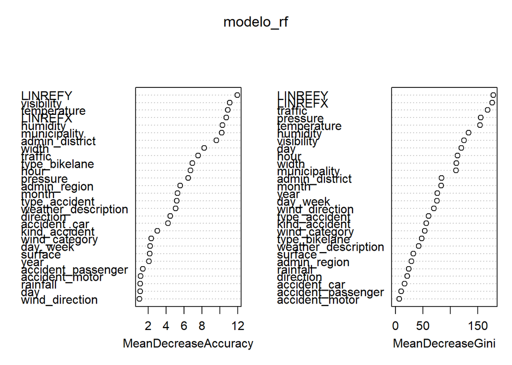

```r
varImpPlot(modelo_rf)
```

## 2. Random Forest con datos balanceados

Dado que el dataset original presenta un fuerte desbalance entre las clases, utilizamos la función upSample() del paquete caret para equilibrar las clases mediante sobremuestreo.

```r
x <- train[, setdiff(names(train), "category")]
y <- train$category

# Hacemos sobremuestreo para balancear clases
train_bal <- upSample(x = x, y = y)

# La variable de clase queda renombrada como "Class" por defecto
table(train_bal$Class)
```

```
    1     2     3
12498 12498 12498
```

Realizamos random forest con los datos balanceados

```r
modelo_rf_bal <- randomForest(Class ~ ., data = train_bal, ntree = 500, importance = TRUE)
```

```r
pred_bal <- predict(modelo_rf_bal, newdata = test)
confusionMatrix(pred_bal, test$category)
```

```
Confusion Matrix and Statistics

          Reference
Prediction    1    2    3
         1    0    0    0
         2    0    5    4
         3    7  524 5370

Overall Statistics

               Accuracy : 0.9095
                 95% CI : (0.9019, 0.9167)
    No Information Rate : 0.9093
    P-Value [Acc > NIR] : 0.4934

                  Kappa : 0.0154

 Mcnemar's Test P-Value : NA

Statistics by Class:

                     Class: 1 Class: 2 Class: 3
Sensitivity          0.000000 0.009452 0.999256
Specificity          1.000000 0.999257 0.009328
Pos Pred Value            NaN 0.555556 0.910015
Neg Pred Value       0.998816 0.911201 0.555556
Prevalence           0.001184 0.089509 0.909306
Detection Rate       0.000000 0.000846 0.908629
Detection Prevalence 0.000000 0.001523 0.998477
Balanced Accuracy    0.500000 0.504354 0.504292
```

Como vemos en los resultados el modelo con los datos balanceados ha sido igual de poco eficaz que con los datos desbalanceados.

## 3. XGBoost

Con el modelo Random Forest hemos tenido dificulatades para predecir correctamente las clases minoritarias debido a un fuerte desbalance en los datos. Por ello probaberemos a continuación otros modelos más robustos como **XGBoost**.

A continuación prepararemos los datos para aplicar XGBoost.

```r
# Creamos una copia del dataset limpio
df_model <- df %>%
  dplyr::select(-accident_other, -road_surface_condition, -accident_goodsroad, -sunshine_minutes) %>%
  na.omit()

# Reindexamos las categorías como 0, 1, 2
df_model$category <- as.integer(as.factor(df_model$category)) - 1

# Dividimos entre entrenamiento y test
set.seed(123)
train_index <- sample(1:nrow(df_model), 0.7 * nrow(df_model))
train <- df_model[train_index, ]
test <- df_model[-train_index, ]

# Separamos variables y etiquetas
X_train <- as.matrix(train %>% dplyr::select(-category))
y_train <- train$category

X_test <- as.matrix(test %>% dplyr::select(-category))
y_test <- test$category

# Creamos DMatrix para XGBoost
dtrain <- xgb.DMatrix(data = X_train, label = y_train)
dtest <- xgb.DMatrix(data = X_test, label = y_test)
```

Una vez preparados los datos creamos el modelo y calculamos las predicciones.

```r
# Número de clases
num_class <- length(unique(y_train))

# Parámetros del modelo
params <- list(
  objective = "multi:softmax",
  num_class = num_class,
  eval_metric = "mlogloss",
  eta = 0.1,
  max_depth = 6
)

# Entrenamos al modelo
xgb_model <- xgb.train(
  params = params,
  data = dtrain,
  nrounds = 100,
  watchlist = list(train = dtrain),
  verbose = 0
)

# Realizamos las predicciones
pred_xgb <- predict(xgb_model, newdata = dtest)
```

Evaluamos la precisión global y presentamos la matriz de confusión.

```r
# Matriz de confusión
confusion <- confusionMatrix(as.factor(pred_xgb), as.factor(y_test))
confusion
```

```
Confusion Matrix and Statistics

          Reference
Prediction    0    1    2
         0    0    0    0
         1    0    1    6
         2    7  528 5368

Overall Statistics

               Accuracy : 0.9085
                 95% CI : (0.9008, 0.9157)
    No Information Rate : 0.9093
    P-Value [Acc > NIR] : 0.6006

                  Kappa : 0.0014

 Mcnemar's Test P-Value : NA

Statistics by Class:

                     Class: 0  Class: 1 Class: 2
Sensitivity          0.000000 0.0018904 0.998884
Specificity          1.000000 0.9988850 0.001866
Pos Pred Value            NaN 0.1428571 0.909368
Neg Pred Value       0.998816 0.9105540 0.142857
Prevalence           0.001184 0.0895093 0.909306
Detection Rate       0.000000 0.0001692 0.908291
Detection Prevalence 0.000000 0.0011844 0.998816
Balanced Accuracy    0.500000 0.5003877 0.500375
```

De los resultados obtenidos, vemos que con XGBoost obtenemos praticamente los mismos resultados que con Random Forest.

Finalmente mostramos la importancia de cada variable en el modelo.

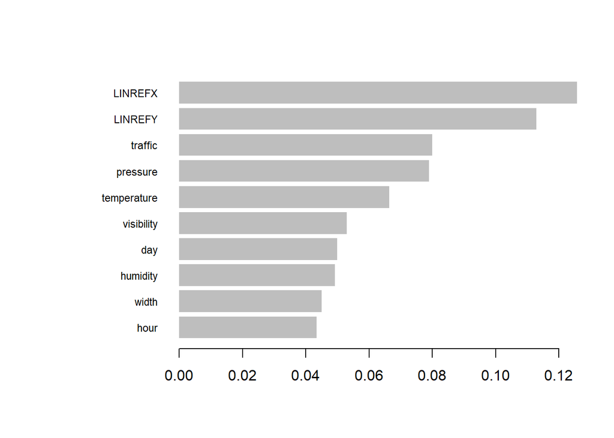

```r
xgb.importance(model = xgb_model) %>%
  xgb.plot.importance(top_n = 10)
```